# Reproducible Research Assignment 1

Khudodod Khudododov

2022-09-09

# Preparing the data

This stage will take two steps; reading the data and processing

### Reading the data

```r
url<-download.file("https://d396qusza40orc.cloudfront.net/repdata%2Fdata%2Factivity.zip",destfile = "repdata1")
unzip('repdata1')

df_activity<-read.csv("activity.csv",header = TRUE)
```

### Processing data

The first think I do after reading the data is to convert the date column into a proper date format. Second, I will extract the weekdays and the month from the date variable to use later in the analysis. And finally, I will create the analytic data by calculating the total number of steps for each day, which I will use to answer the first question.

```r
dim(df_activity)
```

```
## [1] 17568     3
```

```r
str(df_activity)
```

```
## 'data.frame':    17568 obs. of  3 variables:
##  $ steps   : int  NA NA NA NA NA NA NA NA NA NA ...
##  $ date    : chr  "2012-10-01" "2012-10-01" "2012-10-01" "2012-10-01" ...
##  $ interval: int  0 5 10 15 20 25 30 35 40 45 ...
```

```r
## convert date to date format
df_activity<-df_activity%>%
  mutate(date=ymd(date))

df_activity<-df_activity%>%
  mutate(interval_week=weekdays(date),
         interval_month=month(date))
## create the analytic data
## aggregate the steps taken over the date variable. This is basically the sum of the total
## number of steps taken each day, i.e, the sum over all 5 minute intervals
df_analytic<-df_activity%>%
  group_by(date)%>%summarise(steps=sum(steps))
```

### Analysis

#### Mean total number of steps taken per day

1. Histogram of the total number steps taken each day

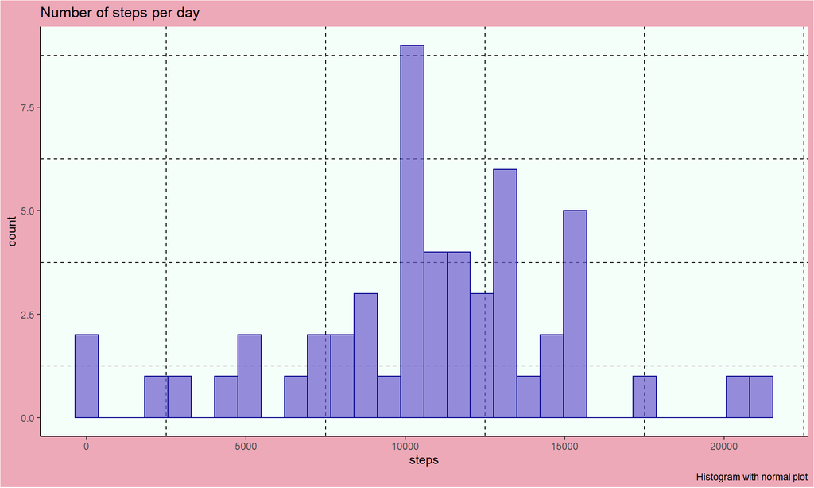

```r
plot1<-df_analytic%>%
  ggplot(.,aes(x=steps))+
  geom_histogram(fill="slateblue",alpha=0.7,color="darkblue")+
  theme_classic()+
  labs(title="Number of steps per day",
       caption = "Histogram with normal plot")+
  theme(plot.background = element_rect(fill = "pink2"),
        panel.background = element_rect(fill="mintcream"),
        panel.grid.minor = element_line(linetype = 2,color = "black"))

plot1
```

The histogram above shows the total number of steps taken each day.

2. **Mean** and **Median** total steps taken

| mean_step | median_step |
| --- | --- |
| 10,766.19 | 10,765 |

Interestingly, the *mean* and *median* steps taken does not differ from one another.

#### What is the average daily activity pattern

1. Average steps taken for each interval: time series plot

To create the series plot, I will first calculate the average steps in each interval storing it as a variable in the data. I will then construct the time series plot using *ggplot2* package.

```r
df_activity<-df_activity%>%
  group_by(interval)%>%mutate(avg_steps_interval=mean(steps,na.rm = TRUE))
```

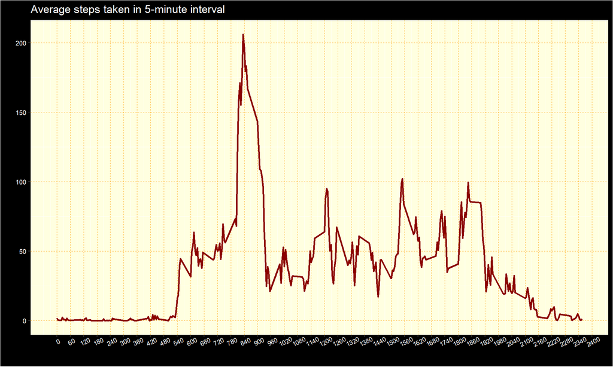

```r
plot2<-df_activity%>%
  ggplot(.,aes(x=interval,y=avg_steps_interval))+
  geom_line(lty=1,lwd=1,colour="darkred")+scale_x_continuous(breaks = seq(0,2400,by=60))+
  labs(title = "Average steps taken in 5-minute interval",y="average steps taken")+
  theme(plot.background = element_rect(fill = "black"),
        panel.background = element_rect(fill="lightyellow"),
        panel.grid.major = element_line(linetype=2,size = 0.001,color = "orange"),
        axis.text.x = element_text(size = 7.5,angle = 25,colour = "white"),
        axis.text.y = element_text(size = 7.5,color = "white"),
        plot.title = element_text(colour = "white"))

plot2
```

2. Maximum steps for specific interval

To find the maximum steps in each interval, use *which.max* command to locate the row position at the interval has the maximum average steps. Then I will select those rows and the specific columns.

```r
which.max(df_activity$avg_steps_interval)
```

```
## [1] 104
```

```r
flextable::flextable(df_activity[103:105,3:4])
```

| interval | interval_week |
| --- | --- |
| 830 | Monday |
| 835 | Monday |
| 840 | Monday |

#### Imputing missing values

1. Total number of missing values in the data

This number is **2304**

2. Imputation strategy

As a simple method, I will use the average steps in each interval and replace the missing values. One can also use a regression based approach or more sophisticated machine learning models. I will the code on how regression can be used to impute. There are also imputation packages that can be used such as the *Mice* package or *Amelia*.

3. Create new dataset with newly imputed values

```r
fit<-lm(steps~interval+interval_week,data = df_activity)

df_activity<-df_activity%>%
  group_by(interval)%>%mutate(median_total_steps=median(steps,na.rm = TRUE))

df_activity<-df_activity%>%
  mutate(steps_imputed=ifelse(is.na(steps),predict(fit,df_activity,type = "response"),steps),
         steps_imputed_mean=ifelse(is.na(steps),avg_steps_interval,steps))
```

4. Histogram of the steps

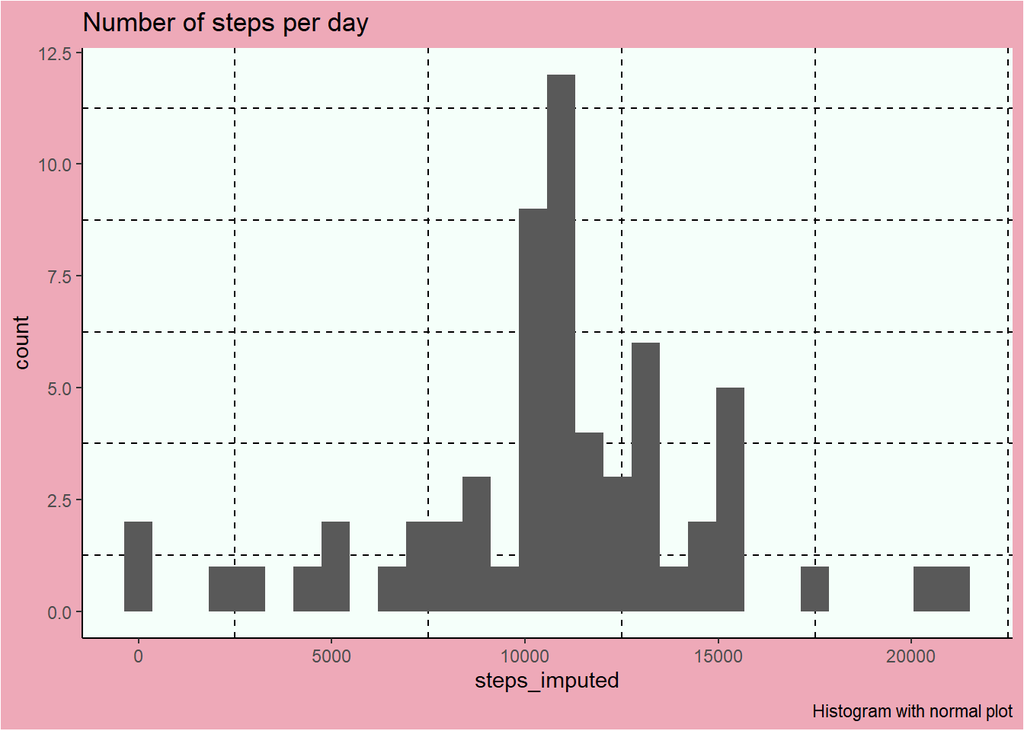

```r
plot3<-df_activity%>%
  group_by(date)%>%
  summarise(steps_imputed=sum(steps_imputed_mean))%>%
  ggplot(.,aes(x=steps_imputed))+
  geom_histogram()+
  theme_classic()+
  labs(title="Number of steps per day",
       caption = "Histogram with normal plot")+
  theme(plot.background = element_rect(fill = "pink2"),
        panel.background = element_rect(fill="mintcream"),
        panel.grid.minor = element_line(linetype = 2,color = "black"))

plot3
```

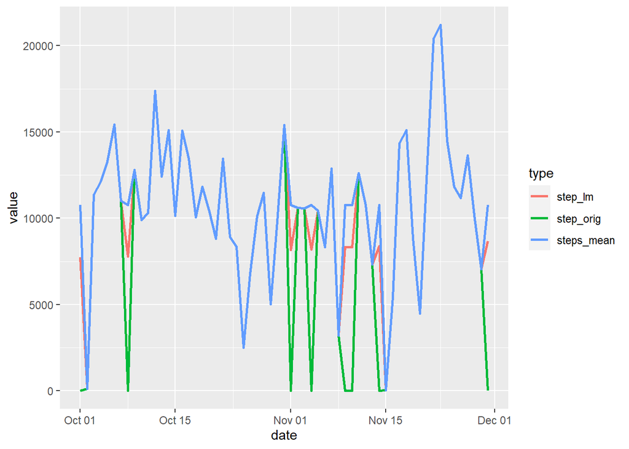

```r
plot4<-df_activity%>%group_by(date)%>%summarise(steps_mean=sum(steps_imputed_mean),step_lm=sum(steps_imputed),step_orig=sum(steps,na.rm = TRUE))%>%gather(key = "type",value = "value",-date)%>%ggplot(.,aes(x=date,y=value,color=type))+geom_line(lty=1,lwd=1)

plot4
```

5. Mean and median

| mean_step | median_step |
| --- | --- |
| 10,766.19 | 10,766.19 |

#### Differences in activity patterns for Weekdays and Weekend

In this final part, I will look at the difference in activity pattern depending on the day of the week. In other words, I will compare the weekdays steps taken to the weekend steps taken to see if there discernible differences. First, I will create the factor variable *day_type* to differentiate between *weekend* and *weekdays* and then I will create a graph using *ggplot2* package. While, the plot looks different from the *example* plot provided, it provides the answer to the question in a similar fashion as the lattice graph would.

1. Create factor variable for Weekend and Weekdays

```r
df_activity<-df_activity%>%
  mutate(day_type=ifelse(interval_week %in% c("Saturday","Sunday"),"Weekend","Weekdays"))

df_activity<-df_activity%>%
  group_by(day_type,interval)%>%
  mutate(avg_steps_interval1=mean(steps,na.rm = TRUE))
```

2. Average steps for each interval by type of day: Weekend or Weekdays

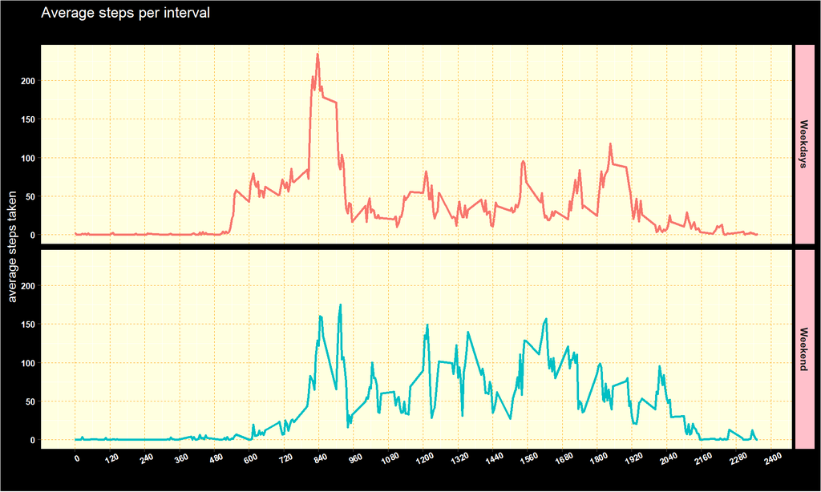

```r
plot5<-df_activity%>%
  ggplot(.,aes(x=interval,y=avg_steps_interval1,color=day_type))+
  geom_line(show.legend = FALSE,lty=1,lwd=1)+scale_x_continuous(breaks = seq(0,2400,by=120))+
  facet_grid(day_type~.)+
  labs(title = "Average steps per interval",subtitle = "Weekend vs Weekdays",
       y="average steps taken",x="")+
  theme(plot.title = element_text(color = "white"),
        plot.background = element_rect(fill="black"),
        panel.background = element_rect(fill="lightyellow"),
        panel.grid.major = element_line(color = "orange",linetype = 2,size = 0.001),
        axis.text.x = element_text(color = "white",face = "bold",size = 7.5,angle = 25),
        axis.title.y = element_text(color = 'White'),
        axis.text.y = element_text(color = "white",size = 7.5,face = "bold"),
        strip.background = element_rect(fill = "pink"),
        strip.placement = "outside",
        strip.text = element_text(face = "bold"))

plot5
```